# Why people wash meat (or don't)

YouTuber (and former public radio reporter) [Adam Ragusea](https://www.youtube.com/user/aragusea/about) [asked his viewers](https://youtu.be/U_PMnCpaJiQ?t=742) in September 2020 to answer a detailed survey about whether (and why and how) they wash meat before cooking it. He received more than 13,000 responses. The data explored and analyzed here is the anomymized data collected. Ragusea published a [video](https://www.youtube.com/watch?v=90Nd_vh3yk8) explaining more around washing meat and his analysis of the data.

*Due to the nature of how this data was gathered this was NOT a random sample. Therefore results, analyses, conclusions, and insights should be treated as such.*

> The aspects analyzed from this survery and that are explored in this document include:
> - **About the Respondents** - What are the demographics of the respondents?
> - **Kitchen Practices** - What are the practice in the kitchen when handling meat? How are the practices different based on types of meat?
> - **Safety Practices** - Is there a difference based on expectations of a commericial versus a home kitchen?

#### Related additional resources/reading:

- [USDA Study: Food Safety Consumer Research Project: Meal Preparation Experiment Related to Poultry Washing](https://www.fsis.usda.gov/wps/wcm/connect/9bb3a252-e12e-40e5-b76b-cb46a2322c3f/FSCRP_Year+2_Final_Aug2019.pdf?MOD=AJPERES) - Published: August 2019
- ["Don't Wash Your Chicken!" Results of an Interdiciplinary Approach to Reduce Incidence of Infectious Foodborne Diseases](https://idea.library.drexel.edu/islandora/object/idea%3A4369/datastream/OBJ/view) - December 2013

### About the Respondents

It is important to keep in mind that due to the nature of how this data was gathered, this is NOT a random sample. Therefore results, analyses, conclusions, and insights should be treated as such. This is more comparable to a market research study.

# Who are these people that responded?

Overall, the survey received 13,527 after it was first launched in September 2020.

As seen in some of the various breakdowns of demographics -- the respondents are not evenly distributed at all. Continue below to view the breakdown in gender, country of residence, race, and age as examples.

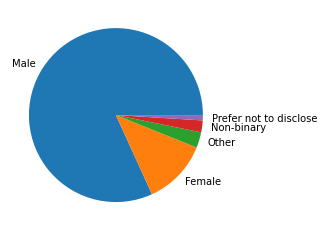

```python
# gender proportion - pie chart
pie_gender = df_survey['gender'].value_counts()
plt.pie(pie_gender, labels=pie_gender.index);
```

```
=== Top 10 country_residency Respondents ===

United States of America                                6343
Canada                                                   898
United Kingdom of Great Britain and Northern Ireland     860
Germany                                                  569
Australia                                                418
Sweden                                                   318
Netherlands                                              286
Poland                                                   259
Brazil                                                   231
Denmark                                                  145
Name: country_residency, dtype: int64
```

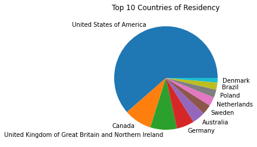

```python
df_top10 = top(df_survey, 'country_residency')

plt.pie(df_top10, labels=df_top10.index)
plt.title('Top 10 Countries of Residency');
```

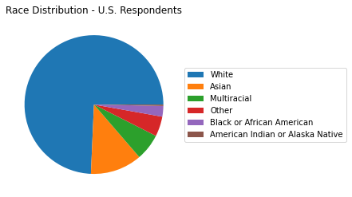

```python
# race distribution with 'Did not respond'
race_graph2 = race_revised['race'].value_counts()
wedges = plt.pie(race_graph2)
plt.legend(wedges, labels = race_graph2.index, loc ='center left', bbox_to_anchor=(1, 0, 0.5, 1))
plt.title('Race Distribution - U.S. Respondents');
```

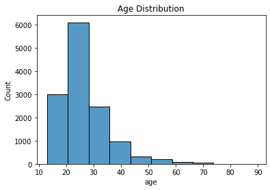

```python
# age - histogram
sns.histplot(data=df_survey, x="age", bins=10)

plt.title('Age Distribution');
```

## Kitchen Practices

Among the questions surveying information on how people treat meat and there practices in the kitchen included the following:

Respondents could answer from one of the following options for each of the questions below:  
Always | Usually | Sometimes | About Half the time | Seldom | Never

Please indicate how often you do each of the following:

- Use different plates for handling raw meat and cooked meat
- Use a food thermometer to check the doneness for red meat, pork or poultry
- Not wash utensils used to handle raw food before they are used for cooked food
- Use the same cutting board without cleaning it with hot soapy water between using it for raw meat or chicken and using it for ready-to-eat food

There were two strong areas where most of respondents showed agreement in their practices:

1. Respondents **ALWAYS** use different plates for handling raw meat and cooked meat
2. Respondents **NEVER** use the same cutting board without cleaning it with hot soapy water between using it for raw meat or chicken and using it for ready-to-eat food

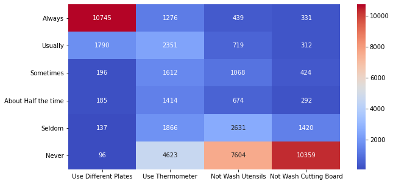

```python
f, ax = plt.subplots(figsize=(10,5))
sns.heatmap(items, annot=True, ax=ax, cmap="coolwarm", fmt="d");
```

## Kitchen Practices

# So, do people wash their meat?

It depends on the meat. The survey asked if respondents "WASH" or "DO NOT WASH" their raw meat in food preparation based on the type of meat. The types of meat listed were:

- Pork (pigs)
- Poultry (chicken, turkey, duck, any other bird)
- Beef (cattle or buffalo)
- Sheep (lamb) or goat
- Fish (marine, fresh water, finned, shellfish, etc.)
- Ground meat
- Other

Overall, respondents overwhelmingly said they do NOT wash their meat -- no matter the type. The largest difference between wash and not wash was for ground meat. Fish was the closest with -- but still a sigificant difference.

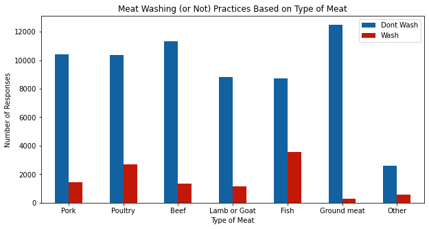

```python
item2.T.plot.bar(rot=0, figsize = (10,5), color=['#1261A0', '#C21807'])

# graph labels
plt.title('Meat Washing (or Not) Practices Based on Type of Meat')
plt.ylabel('Number of Responses')
plt.xlabel('Type of Meat');
```

## Safety Practices

Respondents were asked

- 'When you eat at someone's house, how important is it to you that they be attentive to food safety in their food preparation?'
- 'When you eat at a commercial eatery, how important is it to you that they be attentive to food safety in their food preparation?'

For a commerical eatery, there was a noticable pattern of safety being extremely important with '5' being the top choice then a decline to '1'. Meanwhile, when eating at someone's house the top answer was a '4' with '5' and '3' being almost tied for the second most popular answer.

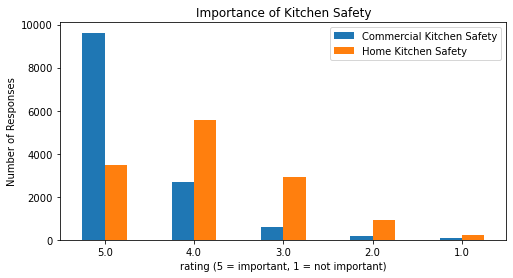

```python
item3_reverse.plot.bar(figsize=(8,4), rot=0)
plt.title('Importance of Kitchen Safety');
plt.xlabel('rating (5 = important, 1 = not important)')
plt.ylabel('Number of Responses');
```